LAPORAN PRAKTIKUM METODE STATISTIKA

| Dosen: | Asisten: |
| --- | --- |
| Dr. Epha Diana Supandi, S.Si, M.Si. | 1. Hanifah Rahmawati |
|  | 2. Yogi Anggara |

# Tugas 1

30/3/2021

Kembali pada kasus PT. METSTAT. Setelah kamu memberikan hasil analisis kemarin, manajer memuji hasil analisis kamu! Manajer pun mengusulkan kamu untuk mempresentasikan hasil analisis kamu pada rapat nanti. Namun sebelum itu, manajer meminta kamu untuk memvisualisasikan hasil analisis kamu terlebih dahulu. DI samping untuk mempercantik slide presentasi, visualisasi data berguna untuk mempermudah dalam menjelaskan hasil analisis pada divisi-divisi yang masih awam akan statistika.

Note: Data tetap menggunakan `Social_Network_Ads.csv` (https://www.kaggle.com/rakeshrau/social-network-ads) . Khusus nomor 6 menggunakan data `sales_data_sample_grouped.csv` (https://www.kaggle.com/kyanyoga/sample-sales-data)

# Soal 1

Visualisasikan distribusi data usia pengguna. Plot apa yang sebaiknya digunakan? Berikan alasan dan informasi yang diperoleh dari visualisasi tersebut!

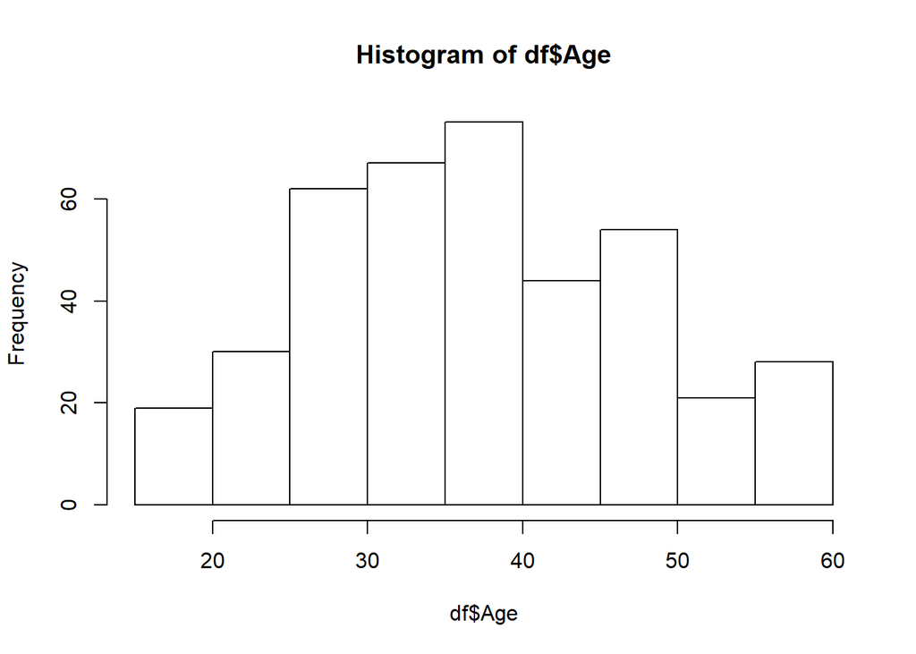

```r
df = read.csv("data/Social_Network_Ads.csv")
hist(df$Age)
```

# Soal 2

Visualisasikan banyak pengguna berdasarkan kelompok usia:

- 15-24 tahun: Kelompok usia muda
- 25-34 tahun: Kelompok usia pekerja awal
- 35-44 tahun: Kelompok usia paruh baya
- 45-54 tahun: Kelompok usia pra-pensiun
- 55-64 tahun: Kelompok usia pensiun

<sub>*Source: https://sepakat.bappenas.go.id/wiki/Kelompok_Usia*</sub>

Plot apa yang sebaiknya digunakan? Berikan alasan dan informasi yang diperoleh dari visualisasi tersebut!

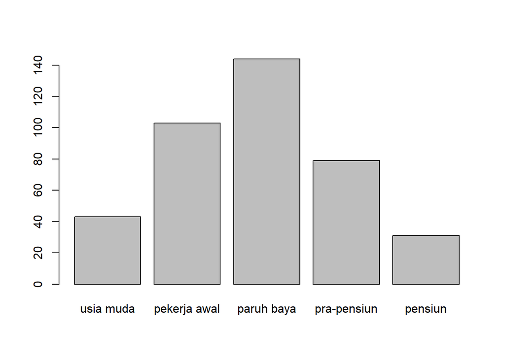

```r
usia_muda = length(subset(df$Age, df$Age >= 15 & df$Age <= 24))
pekerja_awal = length(subset(df$Age, df$Age >= 25 & df$Age <= 34))
paruh_baya = length(subset(df$Age, df$Age >= 35 & df$Age <= 44))
pra_pensiun = length(subset(df$Age, df$Age >= 45 & df$Age <= 54))
pensiun = length(subset(df$Age, df$Age >= 55 & df$Age <= 64))

label = c("usia muda", "pekerja awal", "paruh baya", "pra-pensiun", "pensiun")
frekuensi = c(usia_muda, pekerja_awal, paruh_baya, pra_pensiun, pensiun)

barplot(frekuensi, names.arg = label)
```

# Soal 3

Visualisasikan perbandingan jumlah pengguna laki-laki dan perempuan yang berada pada kelompok usia pekerja awal. Plot apa yang sebaiknya digunakan? Berikan alasan dan informasi yang diperoleh dari visualisasi tersebut!

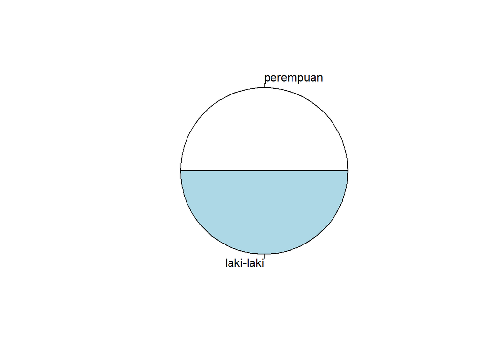

```r
pekerja_awal.lk = length(subset(df, df$Age >= 25 & df$Age <= 34 & df$Gender == "Male"))
pekerja_awal.pr = length(subset(df, df$Age >= 25 & df$Age <= 34 & df$Gender == "Female"))
frekuensi = c(pekerja_awal.pr, pekerja_awal.lk)
label = c("perempuan", "laki-laki")

pie(frekuensi, labels = label)
```

# Soal 4

Visualisasikan perbandingan distribusi data gaji pengguna yang membeli produk dengan yang tidak. Plot apa yang sebaiknya digunakan? Berikan alasan dan informasi yang diperoleh dari visualisasi tersebut!

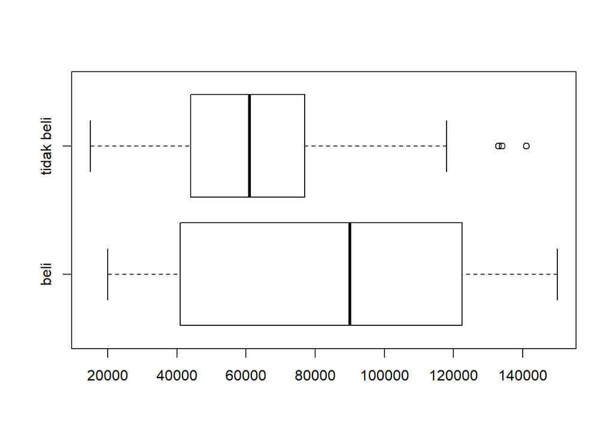

```r
df.beli = subset(df, df$Purchased == 1)
df.g_beli = subset(df, df$Purchased == 0)
boxplot(df.beli$EstimatedSalary, df.g_beli$EstimatedSalary,
        horizontal = TRUE,
        names = c("beli", "tidak beli"))
```

# Soal 5

Visualisasikan hubungan/korelasi antara usia dengan gaji pengguna yang membeli produk. Plot apa yang sebaiknya digunakan? Berikan alasan dan informasi yang diperoleh dari visualisasi tersebut!

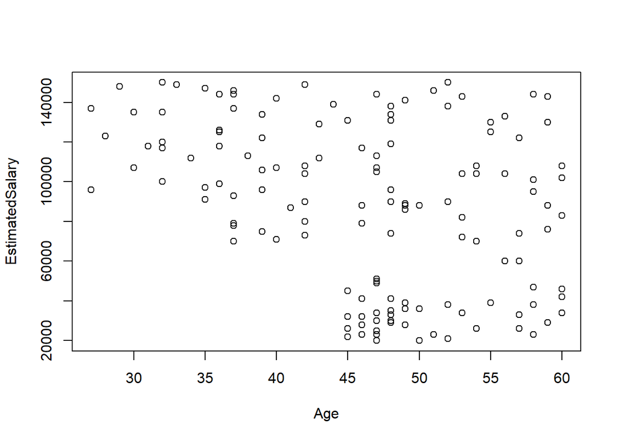

```r
plot(subset(df, df$Purchased == 1)[, c(3,4)])
```

# Soal 6

Visualisasikan data jumlah penjualan tahun lalu tiap bulannya. Plot apa yang sebaiknya digunakan? Berikan alasan dan informasi yang diperoleh dari visualisasi tersebut!

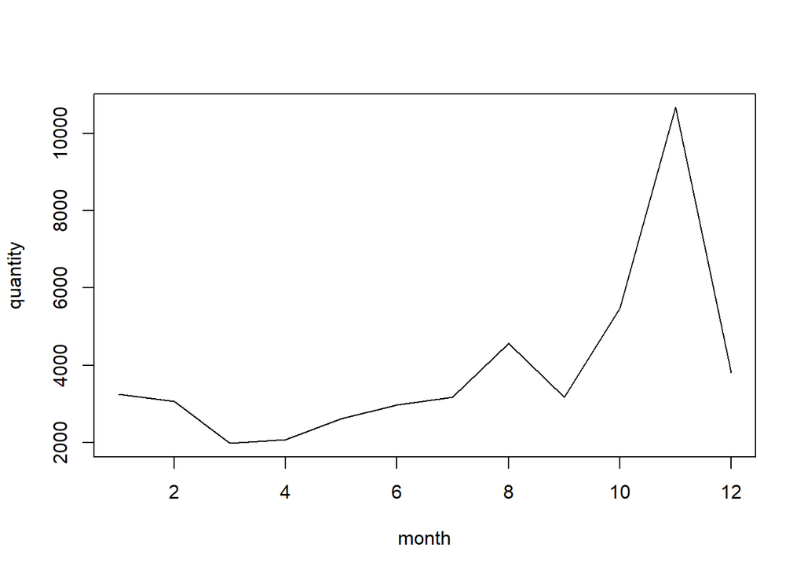

```r
df.penjualan = read.csv("data/sales_data_sample_grouped.csv")
plot(df.penjualan, type="l")
```

# Grouping

Ngga usah dijalanin

```r
library(dplyr)
df = read.csv("data/sales_data_sample.csv")

# select and grouping data
df_grouped =
  df %>%
  filter(YEAR_ID == 2004) %>%
  select(MONTH_ID, QUANTITYORDERED) %>%
  group_by(MONTH_ID) %>%
  summarise(QUANTITYORDERED = sum(QUANTITYORDERED)) %>%
  rename(month = MONTH_ID, quantity = QUANTITYORDERED) %>%
  arrange(month)
# save to csv
write.csv(df_grouped, "data/sales_data_sample_grouped.csv", row.names = FALSE)
```